[O’Hara on GitHub](https://github.com/oharac)

# MPAs and biodiversity intactness - conservation-focused MPAs

Compiled on Sat Aug 31 11:32:49 2019 by ohara

```r
knitr::opts_chunk$set(fig.width = 6, fig.height = 4, fig.path = 'figs/',
                      echo = TRUE, message = FALSE, warning = FALSE)

library(raster)
library(data.table)

source('https://raw.githubusercontent.com/oharac/src/master/R/common.R')
  ### includes library(tidyverse); library(stringr);
  ### dir_M points to ohi directory on Mazu; dir_O points to home dir on Mazu

dir_git <- here()

source(file.path(dir_git, '_setup/common_fxns.R'))
```

# 1 Summary

Compare MPAs to biodiversity risk.

# 2 Data sources

- IUCN species API: IUCN. (2019). The IUCN Red List of Threatened Species. Version 2019-2.
- IUCN species shapefiles: IUCN. (2019). The IUCN Red List of Threatened Species. Version 2019-2. Retrieved August 2019, from http://www.iucnredlist.org
- BirdLife International shapefiles: BirdLife International and Handbook of the Birds of the World. (2018). Bird species distribution maps of the world. Version 7.0. Available at http://datazone.birdlife.org/species/requestdis
- World Database on Protected Areas: IUCN, & UNEP-WCMC. (2018, June). The World Database on Protected Areas (WDPA). Retrieved June 9, 2018, from Cambridge, UK: UNEP-WCMC website: www.protectedplanet.net
- Marine Ecoregions of the World: Spalding, M. D., Fox, H. E., Allen, G. R., Davidson, N., Ferdaña, Z. A., Finlayson, M. A. X., … others. (2007). Marine ecoregions of the world: A bioregionalization of coastal and shelf areas. BioScience, 57(7), 573–583.

# 3 Methods

## 3.1 Compare MPA coverage to biodiversity risk

MPA coverage will be compared to non-MPA areas within EEZs. The .csv codes MPAs as their numeric IUCN category (i.e. Ia = Ib = 1, II = 2, …, VI = 6); areas that are specifically designated as no-take (that are not already in categories Ia, Ib, and II) are coded as -1; areas that are designated in the WDPA database but do not fall into one of these categories are coded as 8.

```r
mean_rast     <- raster(file.path(dir_output, 'mean_risk_raster_comp.tif'))
eez_rast      <- raster(file.path(dir_spatial, 'eez_rast.tif'))
ocean_area_rast <- raster(file.path(dir_spatial, 'ocean_area_rast.tif'))

rgn_labels <- read_csv(file.path(dir_spatial, 'rgn_names.csv')) %>%
  mutate(r1_label = str_replace(r1_label, 'Americas', 'N. America'),
         r1_label = str_replace(r1_label, 'Latin Am.+', 'S. America'),
         r1_label = ifelse(str_detect(r2_label, 'Central America|Caribbean'),
                           'C. America/Caribbean', r1_label),
         r1_label = ifelse(rgn_id == 135, 'N. America', r1_label))


risk_df <- data.frame(cell_id   = 1:length(values(mean_rast)),
                      ocean_area = values(ocean_area_rast),
                      eez       = values(eez_rast),
                      mean_risk = values(mean_rast)) %>%
  left_join(rgn_labels, by = c('eez' = 'rgn_id')) %>%
  filter(!is.na(mean_risk))
```

```r
calc_mpa_areas <- function(df) {
  ### ensure MPA area is no larger than ocean area of the cell; and
  ### code NA as zero for means and weights calculations
  df %>%
    mutate(mpa = ifelse(is.na(mpa), 0, mpa),
           mpa = ifelse(mpa > ocean_area, ocean_area, mpa),
           non_mpa = ocean_area - mpa) %>%
    gather(mpa_status, area, mpa, non_mpa) %>%
    mutate(mpa_status = (mpa_status == 'mpa'))
}

mpa_df   <- read_csv(file.path(dir_spatial, 'wdpa_mpa_area.csv'),
                          col_types = 'dddd') %>%
  filter(wdpa_category <= 4) %>%
  select(-wdpa_category) %>%
  group_by(cell_id) %>%
  summarize(mpa = sum(prot_area_km2, na.rm = TRUE))

risk_mpa_df <- risk_df %>%
  left_join(mpa_df, by = 'cell_id') %>%
  calc_mpa_areas()
```

```r
global_conserv <- risk_mpa_df %>%
  filter(eez < 255 & eez != 213) %>%
  mutate(lbl = 'Global EEZ')

highseas_conserv <- risk_mpa_df %>%
  filter(eez > 255 | eez == 213) %>%
  mutate(lbl = 'High seas')

rgn_conserv <- risk_mpa_df %>%
  filter(eez < 255 & eez != 213) %>%
  mutate(lbl = r1_label) %>%
  arrange(lbl)

conserv_df <- bind_rows(global_conserv,
                        rgn_conserv,
                        highseas_conserv) %>%
  mutate(lbl = forcats::fct_inorder(lbl))

prot_pct <- conserv_df %>%
  group_by(lbl) %>%
  summarize(pct_prot = sum(area * mpa_status) / sum(area) * 100,
            tot_area = sum(area))
### this is independent of range-rarity weighting

conserv_means <- conserv_df %>%
  group_by(mpa_status, lbl) %>%
  summarize(mu = sum(mean_risk * area) / sum(area)) %>%
  ungroup()
```

```r
mean_rr_rast      <- raster(file.path(dir_output, 'mean_rr_risk_raster_comp.tif'))

risk_rr_df <- data.frame(cell_id    = 1:length(values(mean_rr_rast)),
                         ocean_area = values(ocean_area_rast),
                         eez        = values(eez_rast),
                         mean_risk  = values(mean_rr_rast)) %>%
  left_join(rgn_labels, by = c('eez' = 'rgn_id')) %>%
  filter(!is.na(mean_risk))
```

```r
risk_mpa_rr_df <- risk_rr_df %>%
  left_join(mpa_df, by = 'cell_id') %>%
  calc_mpa_areas()
```

```r
global_conserv_rr <- risk_mpa_rr_df %>%
  filter(eez < 255 & eez != 213) %>%
  mutate(lbl = 'Global EEZ')

highseas_conserv_rr <- risk_mpa_rr_df %>%
  filter(eez > 255 | eez == 213) %>%
  mutate(lbl = 'High seas')

rgn_conserv_rr <- risk_mpa_rr_df %>%
  filter(eez < 255 & eez != 213) %>%
  mutate(lbl = r1_label) %>%
  arrange(lbl)

conserv_rr_df <- bind_rows(global_conserv_rr,
                           rgn_conserv_rr,
                           highseas_conserv_rr) %>%
  mutate(lbl = forcats::fct_inorder(lbl))

conserv_rr_means <- conserv_rr_df %>%
  group_by(mpa_status, lbl) %>%
  summarize(mu = sum(mean_risk * area) / sum(area)) %>%
  ungroup()
```

There seem to be two philosophies of MPA priority: place MPAs in impacted areas to reduce pressure and prevent further degradation, or place MPAs to protect pristine places to maintain their pristine state. This suggests that we may see a bimodal distribution of mean risk within MPA cells relative to the distribution of mean risk in general.

### 3.1.1 Mean risk

```r
plot_dist <- function(df, means_df, var_name, x_lims = c(0, .6)) {
  x <- ggplot(df, aes(x = mean_risk)) +
    ggtheme_plot(base_size = 7) +
    theme(strip.text.y = element_text(angle = 0, hjust = 0),
          axis.text.y  = element_blank(),
          axis.title   = element_blank(),
          panel.grid.major.y = element_blank(),
          plot.margin = unit(c(.1, .25, .1, .35), 'cm')) +
    geom_density(aes(x = mean_risk, weight = area, ..scaled..,
                     fill = mpa_status, color = mpa_status),
                 alpha = .5, size = .25) +
    geom_vline(data = means_df,
               aes(xintercept = mu, linetype = mpa_status),
               color = 'grey20', alpha = .8) +
    scale_x_continuous(expand = c(0, 0),
                       limits = x_lims,
                       labels = risk_lbls,
                       breaks = risk_brks) +
    scale_y_continuous(expand = c(0, 0)) +
    scale_fill_manual(values  = c('red4', 'cadetblue2')) +
    scale_color_manual(values = c('red3', 'cadetblue4')) +
    facet_grid( lbl ~ ., scales = 'free_y') +
    labs(fill = var_name, color = var_name, linetype = var_name)

  return(x)
}
```

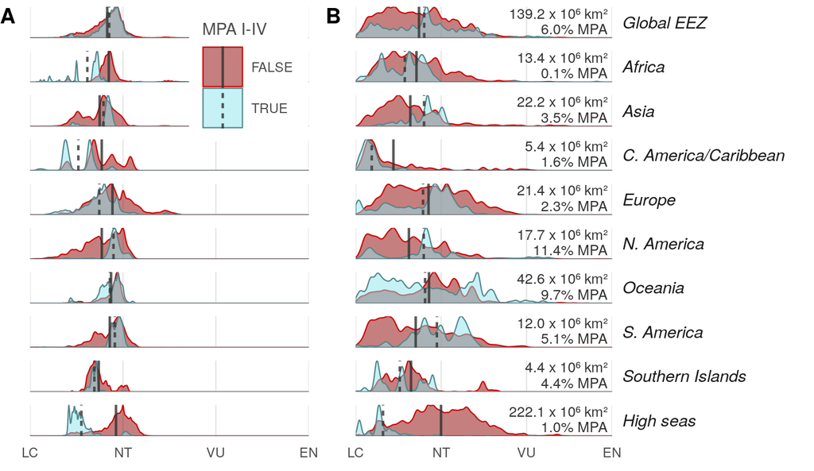

```r
prot_pct_lbls <- prot_pct %>%
  mutate(area_lbl = sprintf('%.1f x 10⁶ km²', tot_area/1e6),
         prot_lbl = sprintf('%.1f%% MPA', pct_prot))

mpa_plot_unweighted <- plot_dist(conserv_df, conserv_means, 'MPA I-IV')

mpa_plot_rrweighted <- plot_dist(conserv_rr_df, conserv_rr_means, 'MPA I-IV') +
  geom_text(data = prot_pct_lbls, aes(x = .59, y = .95, label = area_lbl),
            hjust = 1, size = 2.1, vjust = 1, color = 'grey20') +
  geom_text(data = prot_pct_lbls, aes(x = .59, y = .45, label = prot_lbl),
          hjust = 1, size = 2.1, vjust = 1, color = 'grey20')


plot_combined <- cowplot::plot_grid(mpa_plot_unweighted +
                                      theme(strip.text.y = element_blank(),
                                            legend.justification = c(1, 1),
                                            legend.position = c(1, 1)),
                                    mpa_plot_rrweighted +
                                      theme(legend.position = 'none'),
                                    labels = c('A', 'B'),
                                    label_size = 9,
                                    hjust = 0,
                                    rel_widths = c(2, 3))

ggsave(file.path(dir_git, 'ms_figures/fig_S2a_bd_risk_vs_mpas_i_iv.png'),
       height = 2.75, width = 4.75, dpi = 300, units = 'in')
```

### 3.1.2 unweighted means

| mpa_status | lbl | mu |
| --- | --- | --- |
| FALSE | Global EEZ | 0.1659502 |
| FALSE | Africa | 0.1693628 |
| FALSE | Asia | 0.1497210 |
| FALSE | C. America/Caribbean | 0.1542556 |
| FALSE | Europe | 0.1773314 |
| FALSE | N. America | 0.1543574 |
| FALSE | Oceania | 0.1742807 |
| FALSE | S. America | 0.1715524 |
| FALSE | Southern Islands | 0.1476582 |
| FALSE | High seas | 0.1849282 |
| TRUE | Global EEZ | 0.1702622 |
| TRUE | Africa | 0.1231685 |
| TRUE | Asia | 0.1580536 |
| TRUE | C. America/Caribbean | 0.1038394 |
| TRUE | Europe | 0.1489203 |
| TRUE | N. America | 0.1795284 |
| TRUE | Oceania | 0.1717931 |
| TRUE | S. America | 0.1824391 |
| TRUE | Southern Islands | 0.1383581 |
| TRUE | High seas | 0.1103851 |

### 3.1.3 rr-weighted means

| mpa_status | lbl | mu |
| --- | --- | --- |
| FALSE | Global EEZ | 0.1480751 |
| FALSE | Africa | 0.1421937 |
| FALSE | Asia | 0.1277894 |
| FALSE | C. America/Caribbean | 0.0881945 |
| FALSE | Europe | 0.1703947 |
| FALSE | N. America | 0.1244936 |
| FALSE | Oceania | 0.1714952 |
| FALSE | S. America | 0.1403571 |
| FALSE | Southern Islands | 0.1294261 |
| FALSE | High seas | 0.1996893 |
| TRUE | Global EEZ | 0.1603065 |
| TRUE | Africa | 0.1149122 |
| TRUE | Asia | 0.1599282 |
| TRUE | C. America/Caribbean | 0.0374991 |
| TRUE | Europe | 0.1575839 |
| TRUE | N. America | 0.1592375 |
| TRUE | Oceania | 0.1623127 |
| TRUE | S. America | 0.1899663 |
| TRUE | Southern Islands | 0.1031152 |
| TRUE | High seas | 0.0637930 |

```r
means_to_save <- conserv_means %>%
  left_join(conserv_rr_means %>% rename(mu_rr = mu),
            by = c('lbl', 'mpa_status'))
write_csv(means_to_save, file.path(dir_setup, 'int/mpa_mean_risks_i_iv.csv'))
```